# An Introduction to Control Flow

Specialist Analytics Team (SAT)

# What is Control Flow?

Ordering & Controlling Statements in Code

## Things That Flow

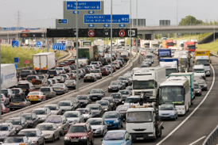

Traffic flow on a busy road.

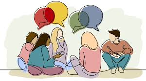

Conversation flowing between people.

## Code Flows Too

- The flow of code and the steps that impact that flow are called “control flow”.
- In general code flows in the way same as a book (with some exceptions).
  - Each function is completed before considering the next.
- Functions can be nested in other functions - the inner most function is completed first.
- Control structures can be used to change the course of a program.
- Repetition structures can be used to repeat a section of code.

# Control Flow Structure

How to Structure Control Flows in Python

## Sequential Structure

- In general code flows like a book reads:
  - Statements (like lines of code) run top to bottom line,
  - Left to right in statement,
  - Each statement being completed before moving to the next.

```python
v = "2"         #stores "2" as a string in 'v'
i = int(v)      #stores v as an integer 'i'
t = type(i)     #stores the type of 'i' as 't'
print(t)        #prints 't'
```

## Nesting Functions and Operations

- We are not limited to a single function or operation per row.
- The previous example could be re-written as:
  - `print(type(int("2")))`
- Nesting functions can be useful, however care should be taken and it may be easier to separate functions over multiple rows.

## Control Structures

- Control structures (also known as decision structures) allow the flow to respond to varying situations.
- A decision is made based on one or more conditions.
- These control structures are very similar to the `IF` function in Excel and the `CASE` statement in SQL (but remember that indentation matters in Python).

[output not shown]

## The Importance of Being Boole(an)

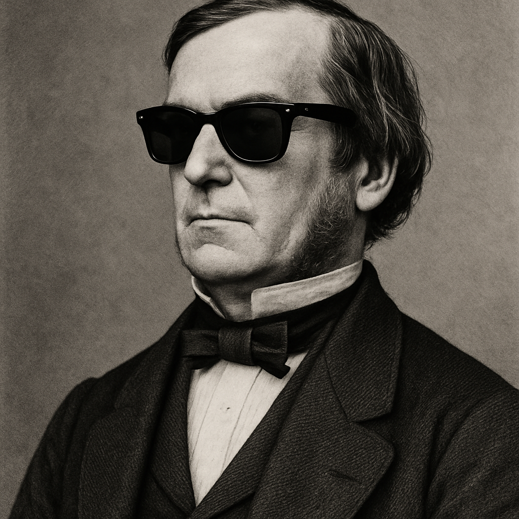

- George Boole was an English Mathmetician and logician whose work on binary logic has resulted in binary conditions bearing his name
- Any statement that can be evaluated as only either `True` (1) or `False` (0) is Boolean.

## Repetition Structures

- Repetition structures (commonly referred to as “loops”) allow for us to recycle chunks of code to perform the same or similar operation a specified number of times or until a condition changes.
- **For** loops cycle through a series of iterations, until they reach the end performing each series of statements for each iteration.
  - This can be used to cycle through a list, dictionary or other iterable as well as working through ranges of numbers
- **While** loops continue until a predetermined condition changes from True to False.
  - This can be useful for testing conditions but comes with a warning:
- *Make sure your condition will change at some point or else your loop cannot end.*

## What is Iterability?

- Iterability is the ability to split an object into discrete items. The item may be ordered or unordered, each item will be extracted, processed ad set aside.
- In general if an object can be split into multiple items it can be iterated (integers and floats are not iterable).
- Iterable objects include:
  - Strings (the word “strings” contains 7 iterable items).
  - Lists eg [1, 2, 3, 4, 4, 4, 5, 6]
  - Tuples eg (12, ‘Red’, ‘Apples’)
  - Sets eg {1, 2, 3, 4, 5, 6}
  - Dict eg {ICB_Code: ‘QSL’, Metric_Code: E.M.10}

# Code Examples

Code Flow Structures in Action

## Sequential Structure Example

- The following sequential code will create a variable called ‘var’ which is a string, it converts this string to an integer and conducts a series of mathematical operators before printing the result:

```python
var = '22' # set "var" to '22'
var = int(var) # convert "var" to int
var = var  / 2 - 3 # apply math operators
print (var) # print result
```

## Control Structure Example

- This code checks if a variable called ‘provider’ in this list is equal to a selection of values and prints out an associated string.

```python
if provider == ‘ryr’:
  print(‘SUSSEX’)
elif provider == ‘rhu’:
  print(‘HIOW’)
elif provider == ‘rxq’:
  print(‘BOB’)
else:
  print(‘Unknown’)
```

## Control Structure Example

```sql
CASE
  WHEN provider = 'ryr'
    THEN 'Sussex'
  WHEN provider = 'rhu'
    THEN 'HIOW'
  WHEN provider = 'rhu'
    THEN 'BOB'
  ELSE 'Unknown'
  END
```

## Watch Out for Unintended Consequences

- Not taking care over your coding can cause big issues. Consider the corner cases and unintended consequences?
- Empty variables, incorrect data types, and misunderstood flow in the structure can affect your program.
- Close the loop! Make sure you know how your loops are being switched off and that it’s possible.
- A cautionary tale: [The Virtual Plague That Nearly Wiped Out The World of Warcraft](https://youtu.be/HFMv_hqinvc)

[figure not shown]

The “Corrupted Blood” Incident - a fairly famous coding error.

## Final Thoughts

- **Don’t worry about memorising any of this!**
- The aim of this session is to give a basic understanding of the logic needed to implement control flow in your program.

## Further Reading

- [Python Tutorial - Control Flow](https://docs.python.org/3/tutorial/controlflow.html)
- [Geeks for Geeks - Control Structures](https://www.geeksforgeeks.org/dsa/control-structures-in-programming-languages/)
- [W3 Schools - if/elif/else Logic](https://www.w3schools.com/python/python_conditions.asp)
- [List Comprehension in Python](https://realpython.com/list-comprehension-python/)

# Thank You!

Contact:

Code & Slides:

[/NHS-South-Central-and-West/code-club](https://github.com/nhs-south-central-and-west/code-club)

… And don’t forget to give us your [feedback](https://forms.office.com/e/g9fnSVPRwE).